# Geração dos dados de síntomas e condições

Juan Carlos Carbajal Ipenza

### Livrarias

```r
library(XML)
library(stringr)
```

## Síntomas

### Carregando dados

Carregando desde o RData que foi salvo. Também pode ser carregado desde qualquer outro arquivo. Sempre que o objeto dos dados carregados seja um dataframe.

```r
load("output/qdscovid_registers.Rda")
head(dados)
```

|  | dataNotificacao | dataInicioSintomas | sintomas | profissionalSaude | condicoes | estadoTeste | dataTeste | tipoTeste | resultadoTeste | sexo | estadoIBGE | municipioIBGE | estadoNotificacaoIBGE | municipioNotificacaoIBGE | idade | dataEncerramento | evolucaoCaso | classificacaoFinal |
| --- | --- | --- | --- | --- | --- | --- | --- | --- | --- | --- | --- | --- | --- | --- | --- | --- | --- | --- |
| 1 | 2020-04-20 | 2020-04-15 | Dor de Garganta, Tosse | Nao | null | Coletado | 2020-04-20 | Indefinido | Indefinido | Masculino | 12 | 1200450 | 12 | 1200401 | 51 | 2020-01-01 | Indefinido | Indefinido |
| 2 | 2020-04-21 | 2020-04-13 | Outros | Nao | null | Coletado | 2020-04-21 | Indefinido | Indefinido | Feminino | 12 | 1200450 | 12 | 1200401 | 47 | 2020-01-01 | Indefinido | Indefinido |
| 3 | 2020-04-22 | 2020-04-12 | Febre, Tosse, Outros | Nao | Doenças cardíacas crônicas, Diabetes | Coletado | 2020-04-22 | Indefinido | Indefinido | Feminino | 12 | 1200401 | 12 | 1200401 | 57 | 2020-01-01 | Indefinido | Indefinido |
| 4 | 2020-03-18 | 2020-03-17 | Febre, Tosse, Outros | Nao | null | Concluido | 2020-03-18 | RT-PCR | Positivo | Feminino | 12 | 1200401 | 12 | 1200401 | 27 | 2020-04-10 | Cura | Lab. |
| 5 | 2020-03-18 | 2020-03-18 | Tosse, Febre, Dor de Garganta, Dispneia, Outros | Sim | null | Concluido | 2020-03-19 | RT-PCR | Positivo | Masculino | 12 | 1200401 | 12 | 1200401 | 30 | 2020-04-10 | Cura | Lab. |
| 6 | 2020-03-24 | 2020-03-17 | Febre | Nao | null | Concluido | 2020-03-24 | RT-PCR | Positivo | Masculino | 12 | 1200401 | 12 | 1200401 | 34 | 2020-04-13 | Cura | Lab. |

```r
summary(dados)
```

```
 dataNotificacao      dataInicioSintomas     sintomas         profissionalSaude  condicoes                       estadoTeste
 Min.   :2020-02-21   Min.   :2020-02-09   Length:42910656    Nao:40647678      Length:42910656    Coletado            : 3963201
 1st Qu.:2020-08-01   1st Qu.:2020-07-26   Class :character   Sim: 2262978      Class :character   Concluido           :31756805
 Median :2020-10-25   Median :2020-10-22   Mode  :character                     Mode  :character   Exame Nao Solicitado: 2412794
 Mean   :2020-10-20   Mean   :2020-10-14                                                           Solicitado          : 2971316
 3rd Qu.:2021-01-09   3rd Qu.:2021-01-02                                                           Indefinido          : 1806540
 Max.   :2021-04-01   Max.   :2021-04-01

   dataTeste               tipoTeste                              resultadoTeste            sexo            estadoIBGE
 Min.   :2020-01-01   ELISA IgM :   60060   Inconclusivo ou Indeterminado:   58470   Feminino :22227479   35     :10934165
 1st Qu.:2020-06-09   ECLIA IgG :   81141   Negativo                     :19889219   Masculino:20683177   31     : 4148110
 Median :2020-09-08   CLIA      :   27260   Positivo                     :10976219                        42     : 4001682
 Mean   :2020-08-23   RT-PCR    :15652759   Indefinido                   :11986748                        43     : 3889102
 3rd Qu.:2020-12-16   ANTICORPO :15703602                                                                 33     : 2829491
 Max.   :2021-03-31   ANTIGENO  : 4063395                                                                 29     : 2595572
                      Indefinido: 7322439                                                                 (Other):14512534
 municipioIBGE      estadoNotificacaoIBGE municipioNotificacaoIBGE     idade        dataEncerramento
 3550308: 2907417   35     : 9113102      3550308   : 2863639      Min.   :  0.00   Min.   :2020-01-01
 4205407: 1852357   42     : 4029429      4205407   : 2012970      1st Qu.: 26.00   1st Qu.:2020-01-01
 3304557: 1034755   43     : 3871653      Indefinido: 1463219      Median : 37.00   Median :2020-01-01
 3106200:  689967   31     : 3817452      4106902   : 1343812      Mean   : 38.58   Mean   :2020-04-24
 2927408:  647340   33     : 2789846      3304557   : 1052356      3rd Qu.: 50.00   3rd Qu.:2020-09-08
 5300108:  543937   29     : 2532947      3106200   :  775374      Max.   :116.00   Max.   :2021-03-31
 (Other):35234883   (Other):16756227      (Other)   :33399286
                   evolucaoCaso       classificacaoFinal
 Indefinido              :25338149   Cli.-Epid.:  283006
 Cura                    :12090024   Cli.-Img. :   10031
 Ignorado                : 2115777   Lab.      : 7976514
 Cancelado               : 2112396   Cri. Cli. :  136385
 Em tratamento domiciliar: 1155882   Desc.     : 8841150
 Obito                   :   71169   SGNE      : 1884354
 (Other)                 :   27259   Indefinido:23779216
```

### Exploração dos dados

```r
summary(dados$sintomas)
```

```
   Length     Class      Mode
 42910656 character character
```

```r
head(dados$sintomas)
```

```
[1] "Dor de Garganta, Tosse"                          "Outros"
[3] "Febre, Tosse, Outros"                            "Febre, Tosse, Outros"
[5] "Tosse, Febre, Dor de Garganta, Dispneia, Outros" "Febre"
```

### Tratamento e limpeza dos dados

Convertendo os nulos a vazios.

```r
unique(dados[grepl("null", dados$sintomas, fixed = TRUE),]$sintomas)
dados[which(dados$sintomas == "null"),]$sintomas = ""

unique(dados[grepl("undefined", dados$sintomas, fixed = TRUE),]$sintomas)
dados[which(dados$sintomas == "undefined"),]$sintomas = ""

dados[is.na(dados$sintomas),]$sintomas = ""
```

Adicionando vírgulas ás palavras que deveriam ter vírgulas.

```r
unique(dados[grepl("Tossedificuldade", dados$sintomas, fixed = TRUE),]$sintomas)
```

```
[1] ",Tossedificuldade De Respirar"      "Febre,Tossedificuldade De Respirar"
```

```r
dados[which(dados$sintomas == ",Tossedificuldade De Respirar"),]$sintomas = "Tosse,Dificuldade De Respirar"
dados[which(dados$sintomas == "Febre,Tossedificuldade De Respirar"),]$sintomas = "Febre,Tosse,Dificuldade De Respirar"

unique(dados[grepl("Febredor", dados$sintomas, fixed = TRUE),]$sintomas)
```

```
[1] "Febredor De Garganta,"                        "Febredor De Garganta,Dispneia"
[3] "Febredor De Garganta,Dificuldade De Respirar"
```

```r
dados[which(dados$sintomas == "Febredor De Garganta,"),]$sintomas = "Febre,Dor de Garganta"
dados[which(dados$sintomas == "Febredor De Garganta,Dispneia"),]$sintomas = "Febre,Dor de Garganta,Dispneia"
dados[which(dados$sintomas == "Febredor De Garganta,Dificuldade De Respirar"),]$sintomas = "Febre,Dor de Garganta,Dificuldade De Respirar"

unique(dados[grepl("Dispneiaoutros", dados$sintomas, fixed = TRUE),]$sintomas)
```

```
 [1] "Febre,Tosse,Dispneiaoutros,"                 "Tosse,Dor De Garganta,Dispneiaoutros,"
 [3] "Tosse,Dispneiaoutros,"                       "Febre,Tosse,Dor De Garganta,Dispneiaoutros,"
 [5] "Febre, Dispneiaoutros,"                      "Dor De Garganta,Dispneiaoutros,"
 [7] "Tosse,Dispneiaoutros"                        "Febre,Tosse,Dispneiaoutros"
 [9] "Febre,Dispneiaoutros"                        "Febre,Tosse,Dor De Garganta,Dispneiaoutros"
[11] "Tosse,Dor De Garganta,Dispneiaoutros"        "Dispneiaoutros"
```

```r
dados[which(dados$sintomas == "Tosse,Dor De Garganta,Dispneiaoutros,"),]$sintomas = "Tosse,Dor De Garganta,Dispneia,Outros"
dados[which(dados$sintomas == "Tosse,Dispneiaoutros,"),]$sintomas = "Tosse,Dispneia,Outros"
dados[which(dados$sintomas == "Febre,Tosse,Dor De Garganta,Dispneiaoutros,"),]$sintomas = "Febre,Tosse,Dor De Garganta,Dispneia,Outros"
dados[which(dados$sintomas == "Febre, Dispneiaoutros,"),]$sintomas = "Febre,Dispneia,Outros"
dados[which(dados$sintomas == "Febre,Tosse,Dispneiaoutros,"),]$sintomas = "Febre,Tosse,Dispneia,Outros"
dados[which(dados$sintomas == "Dor De Garganta,Dispneiaoutros,"),]$sintomas = "Dor De Garganta,Dispneia,Outros"
dados[which(dados$sintomas == "Febre,Tosse,Dispneiaoutros"),]$sintomas = "Febre,Tosse,Dispneia,Outros"
dados[which(dados$sintomas == "Tosse,Dispneiaoutros"),]$sintomas = "Tosse,Dispneia,outros"
dados[which(dados$sintomas == "Dispneiaoutros"),]$sintomas = "Dispneia,Outros"
dados[which(dados$sintomas == "Febre,Tosse,Dor De Garganta,Dispneiaoutros"),]$sintomas = "Febre,Tosse,Dor De Garganta,Dispneia,Outros"
dados[which(dados$sintomas == "Tosse,Dor De Garganta,Dispneiaoutros"),]$sintomas = "Tosse,Dor De Garganta,Dispneia,Outros"
dados[grepl("Dispneiaoutros", dados$sintomas, fixed = TRUE),]$sintomas = "Dispneia,Outros"

unique(dados[grepl("Gargantafebre", dados$sintomas, fixed = TRUE),]$sintomas)
```

```
[1] "Dor De Gargantafebre,Tosse" "Dor De Gargantafebre,"
```

```r
dados[which(dados$sintomas == "Dor De Gargantafebre,Tosse"),]$sintomas = "Dor De Garganta,Febre,Tosse"
dados[which(dados$sintomas == "Dor De Gargantafebre,"),]$sintomas = "Dor De Garganta,Febre"

unique(dados[grepl("Dispneiatosse", dados$sintomas, fixed = TRUE),]$sintomas)
```

```
[1] "Dispneiatosse"                 "Dor De Garganta,Dispneiatosse"
```

```r
dados[which(dados$sintomas == "Dispneiatosse"),]$sintomas = "Dispneia,Tosse"
dados[which(dados$sintomas == "Dor De Garganta,Dispneiatosse"),]$sintomas = "Dor De Garganta,Dispneia,Tosse"

unique(dados[grepl("Febredispneia", dados$sintomas, fixed = TRUE),]$sintomas)
```

```
[1] "Febredispneia"
```

```r
dados[which(dados$sintomas == "Febredispneia"),]$sintomas = "Febre,Dispneia"

save(dados, file = "output/qdscovid_registers.Rda")
rm(dados)
invisible(gc())
```

São extraidos os síntomas num dataframe e é criada uma coluna de contagem de síntomas por registro.

[output not shown]

Salvando a quantidade de síntomas nos dados de registros.

```r
dados$sintomas_count = sintomas$count
summary(dados$sintomas_count)
```

```
   Min. 1st Qu.  Median    Mean 3rd Qu.    Max.
  0.000   1.000   2.000   2.198   3.000  10.000
```

```r
save(dados, file = "output/qdscovid_registers.Rda")
rm(dados)
rm(sintomas)
invisible(gc())
```

É criado um novo dataframe de síntomas duplicando as filas de acordo à fila **count** dos síntomas.

[output not shown]

São salvos o novo dataframe e os síntomas.

```r
dados$sintomas_count = NULL
dados$condicoes = NULL

save(dados, file = "output/qdscovid_symptoms.Rda")
save(sintomas, file = "output/sintomas.Rda")
rm(dados)
rm(sintomas)
invisible(gc())
```

O dataframe dos síntomas é simplificado a uma lista de síntomas.

```r
load("output/sintomas.Rda")
sintomas_list = apply(sintomas, 1, function(x) x[seq_len(x[dim(sintomas)[2]])])
rm(sintomas)
save(sintomas_list, file = "output/sintomas_list.Rda")
rm(sintomas_list)
invisible(gc())
```

Nos novos dados de síntomas são estabelecidos os síntomas corretos na dimensão dos síntomas.

```r
sintomas_list = str_trim(unlist(sintomas_list))
head(sintomas_list)
```

```
[1] "Dor de Garganta" "Tosse"           "Outros"          "Febre"           "Tosse"           "Outros"
```

```r
load("output/qdscovid_symptoms.Rda")
dados$sintomas = sintomas_list
rm(sintomas_list)
invisible(gc())

dados = transform(dados, sintomas = as.factor(sintomas))
head(dados)
```

|  | dataNotificacao | dataInicioSintomas | sintomas | profissionalSaude | estadoTeste | dataTeste | tipoTeste | resultadoTeste | sexo | estadoIBGE | municipioIBGE | estadoNotificacaoIBGE | municipioNotificacaoIBGE | idade | dataEncerramento | evolucaoCaso | classificacaoFinal |
| --- | --- | --- | --- | --- | --- | --- | --- | --- | --- | --- | --- | --- | --- | --- | --- | --- | --- |
| 1 | 2020-04-20 | 2020-04-15 | Dor de Garganta | Nao | Coletado | 2020-04-20 | Indefinido | Indefinido | Masculino | 12 | 1200450 | 12 | 1200401 | 51 | 2020-01-01 | Indefinido | Indefinido |
| 2 | 2020-04-20 | 2020-04-15 | Tosse | Nao | Coletado | 2020-04-20 | Indefinido | Indefinido | Masculino | 12 | 1200450 | 12 | 1200401 | 51 | 2020-01-01 | Indefinido | Indefinido |
| 3 | 2020-04-21 | 2020-04-13 | Outros | Nao | Coletado | 2020-04-21 | Indefinido | Indefinido | Feminino | 12 | 1200450 | 12 | 1200401 | 47 | 2020-01-01 | Indefinido | Indefinido |
| 4 | 2020-04-22 | 2020-04-12 | Febre | Nao | Coletado | 2020-04-22 | Indefinido | Indefinido | Feminino | 12 | 1200401 | 12 | 1200401 | 57 | 2020-01-01 | Indefinido | Indefinido |
| 5 | 2020-04-22 | 2020-04-12 | Tosse | Nao | Coletado | 2020-04-22 | Indefinido | Indefinido | Feminino | 12 | 1200401 | 12 | 1200401 | 57 | 2020-01-01 | Indefinido | Indefinido |
| 6 | 2020-04-22 | 2020-04-12 | Outros | Nao | Coletado | 2020-04-22 | Indefinido | Indefinido | Feminino | 12 | 1200401 | 12 | 1200401 | 57 | 2020-01-01 | Indefinido | Indefinido |

Os dados dos síntomas são salvos na memória e são deletados os outros dados usados para fazer o tratamento.

```r
save(dados, file = "output/qdscovid_symptoms.Rda")
rm(dados)
invisible(gc())

if (file.exists("output/sintomas.Rda")) {
  file.remove("output/sintomas.Rda")
}
```

```
[1] TRUE
```

```r
if (file.exists("output/sintomas_list.Rda")) {
  file.remove("output/sintomas_list.Rda")
}
```

```
[1] TRUE
```

```r
load("output/qdscovid_symptoms.Rda")

counts = table(dados$sintomas)
sort(counts, decreasing = TRUE)
```

```
                                              Outros                                                Tosse
                                            19064744                                             17136686
                                               Febre                                      Dor de Garganta
                                            12799141                                             12215507
                                       Dor de Cabeça                                        Assintomático
                                             8843497                                              7214958
                                              Coriza                                             Dispneia
                                             5696040                                              5604901
                               Distúrbios Gustativos                                 Distúrbios Olfativos
                                             2775054                                              2617503
                      Outros: Paciente assintomático                                      Dor De Garganta
                                              309249                                                26150
                             Dificuldade De Respirar                                            Dispineia
                                                4861                                                  909
                                                                                                 Dispnéia
                                                 689                                                  304
                              Paciente assintomático                                             diarreia
                                                 225                                                   18
                                            diarréia                                      congestão nasal
                                                   8                                                    7
                                     Dor De Gargante                                               outros
                                                   7                                                    7
                                             anosmia                                             calafrio
                                                   5                                                    5
                                              olfato                            perda de olfato e paladar
                                                   3                                                    3
                                            cefaleia                                        cefaleia leve
                                                   2                                                    2
                                           disgeusia                                          dor na face
                                                   2                                                    2
                                        dor no peito                                               Fadiga
                                                   2                                                    2
                                    falta de paladar                                              nauseas
                                                   2                                                    2
                           perca de olfato e paladar                                      perca de palada
                                                   2                                                    2
                                    perda de paladar                            perda de paladar e olfato
                                                   2                                                    2
                                    perda do paladar                                  Tiragem Intercostal
                                                   2                                                    2
```

[output cut: 35 more lines]

```
                                                   1                                                    1
                                     Obstrucao Nasal                                     olfato e paladar
                                                   1                                                    1
              Olhos Hiperemiados Com Secreção Serosa                               perca alfato e paladar
                                                   1                                                    1
                                     perca de olfato                              perca de olfato paladar
                                                   1                                                    1
                                    perda de apetite                           perda de olfato e paladar.
                                                   1                                                    1
                                     perda do cheiro                            perda do paladar e olfato
                                                   1                                                    1
                              perda olfato e paladar                               perda paladar e olfato
                                                   1                                                    1
                                             pigarro                                              Pigarro
                                                   1                                                    1
```

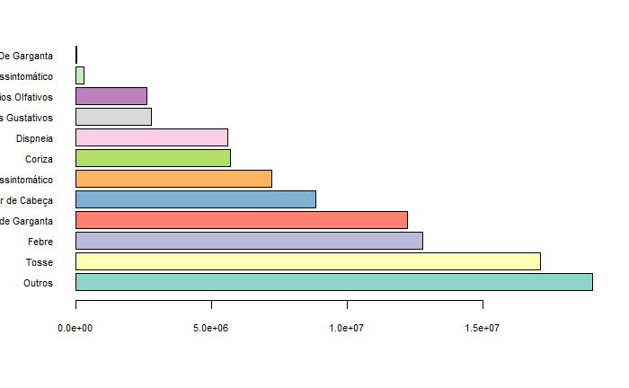

```r
colb = brewer.pal(12, "Set3")
barplot(sort(counts, decreasing = TRUE)[1:12], horiz = TRUE, las = 1, col = colb, cex.names = 0.7, cex.axis = 0.7)
```

```r
rm(counts, colb)
invisible(gc())
```

São tratados os dados por falta de padronização e também os nulos.

```r
dados[dados$sintomas == "calafrios",]$sintomas = "calafrio"
dados[dados$sintomas == "coriza",]$sintomas = "Coriza"
dados[dados$sintomas == "diarréia",]$sintomas = "diarreia"
dados[dados$sintomas == "Dispineia" | dados$sintomas == "Dispnéia",]$sintomas = "Dispneia"
dados[dados$sintomas == "Dor De Cabeça",]$sintomas = "Dor de Cabeça"
dados[dados$sintomas == "Dor De Gargante" | dados$sintomas == "Dor De Garganta",]$sintomas = "Dor de Garganta"
dados[dados$sintomas == "falda de paladar e olfato" | dados$sintomas == "falta de olfato e paladar",]$sintomas = "falta de paladar e olfato"
dados[dados$sintomas == "nausea",]$sintomas = "nauseas"
dados[dados$sintomas == "Outros: Paciente assintomático" | dados$sintomas == "Paciente assintomático",]$sintomas = "Assintomático"

dados$sintomas = factor(dados$sintomas)

counts = table(dados$sintomas)
sort(counts, decreasing = TRUE)
```

```
                                              Outros                                                Tosse
                                            19064744                                             17136686
                                               Febre                                      Dor de Garganta
                                            12799141                                             12241664
                                       Dor de Cabeça                                        Assintomático
                                             8843498                                              7524432
                                              Coriza                                             Dispneia
                                             5696041                                              5606114
                               Distúrbios Gustativos                                 Distúrbios Olfativos
                                             2775054                                              2617503
                             Dificuldade De Respirar
                                                4861                                                  689
                                            diarreia                                      congestão nasal
                                                  26                                                    7
                                              outros                                             calafrio
                                                   7                                                    6
                                             anosmia                            falta de paladar e olfato
                                                   5                                                    3
                                             nauseas                                               olfato
                                                   3                                                    3
                           perda de olfato e paladar                                             cefaleia
                                                   3                                                    2
                                       cefaleia leve                                            disgeusia
                                                   2                                                    2
                                         dor na face                                         dor no peito
                                                   2                                                    2
                                              Fadiga                                     falta de paladar
                                                   2                                                    2
                           perca de olfato e paladar                                      perca de palada
                                                   2                                                    2
                                    perda de paladar                            perda de paladar e olfato
                                                   2                                                    2
                                    perda do paladar                                  Tiragem Intercostal
                                                   2                                                    2
                                          Tosse Seca                                              ageusia
                                                   2                                                    1
                                     alergia na  mao                           anosmia+disgeusia+diarreia
                                                   1                                                    1
                        ausencia de olfato e paladar                                   calafrio congestão
                                                   1                                                    1
```

[output cut: 23 more lines]

```
                                                   1                                                    1
                                    olfato e paladar               Olhos Hiperemiados Com Secreção Serosa
                                                   1                                                    1
                              perca alfato e paladar                                      perca de olfato
                                                   1                                                    1
                             perca de olfato paladar                                     perda de apetite
                                                   1                                                    1
                          perda de olfato e paladar.                                      perda do cheiro
                                                   1                                                    1
                           perda do paladar e olfato                               perda olfato e paladar
                                                   1                                                    1
                              perda paladar e olfato                                              pigarro
                                                   1                                                    1
                                             Pigarro
                                                   1
```

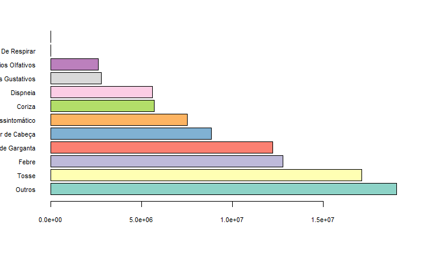

```r
colb = brewer.pal(12, "Set3")
barplot(sort(counts, decreasing = TRUE)[1:12], horiz = TRUE, las = 1, col = colb, cex.names = 0.7, cex.axis = 0.7)
```

```r
rm(counts, colb)
invisible(gc())
```

Deletando os valores nulos e só ficando com síntomas que tem mais de 2000 dados. Os que têm menos são passados para a dimensão **Outros**.

```r
levels(dados$sintomas)
```

```
 [1] "Assintomático"           "Coriza"                  "Dificuldade De Respirar" "Dispneia"
 [5] "Distúrbios Gustativos"   "Distúrbios Olfativos"    "Dor de Cabeça"           "Dor de Garganta"
 [9] "Febre"                   "Outros"                  "Tosse"
```

```r
levels(dados$sintomas) = c("Assint.", "Coriza", "Dif. de resp.", "Dispneia", "Dist. Gusta.", "Dist. Olfa.", "Dor de cab.", "Dor de Garg.", "Febre", "Outros", "Tosse")

save(dados, file = "output/qdscovid_symptoms.Rda")

counts = table(dados$sintomas)

sort(counts, decreasing = TRUE)
```

```
       Outros         Tosse         Febre  Dor de Garg.   Dor de cab.       Assint.        Coriza      Dispneia  Dist. Gusta.
     19064877      17136686      12799141      12241664       8843498       7524432       5696041       5606114       2775054
  Dist. Olfa. Dif. de resp.
      2617503          4861
```

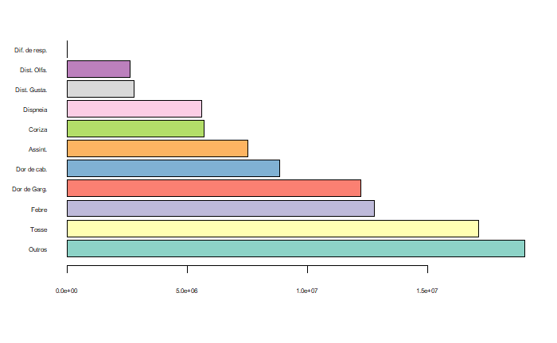

```r
colb = brewer.pal(12, "Set3")
barplot(sort(counts, decreasing = TRUE), horiz = TRUE, las = 1, col = colb, cex.names = 0.5, cex.axis = 0.5)
```

```r
rm(counts, colb)
rm(dados)
invisible(gc())
```

## Condições

### Carregando dados

Carregando desde o RData que foi salvo. Também pode ser carregado desde qualquer outro arquivo. Sempre que o objeto dos dados carregados seja um dataframe.

```r
load("output/qdscovid_registers.Rda")
head(dados)
```

|  | dataNotificacao | dataInicioSintomas | sintomas | profissionalSaude | condicoes | estadoTeste | dataTeste | tipoTeste | resultadoTeste | sexo | estadoIBGE | municipioIBGE | estadoNotificacaoIBGE | municipioNotificacaoIBGE | idade | dataEncerramento | evolucaoCaso | classificacaoFinal | sintomas_count |
| --- | --- | --- | --- | --- | --- | --- | --- | --- | --- | --- | --- | --- | --- | --- | --- | --- | --- | --- | --- |
| 1 | 2020-04-20 | 2020-04-15 | Dor de Garganta, Tosse | Nao | null | Coletado | 2020-04-20 | Indefinido | Indefinido | Masculino | 12 | 1200450 | 12 | 1200401 | 51 | 2020-01-01 | Indefinido | Indefinido | 2 |
| 2 | 2020-04-21 | 2020-04-13 | Outros | Nao | null | Coletado | 2020-04-21 | Indefinido | Indefinido | Feminino | 12 | 1200450 | 12 | 1200401 | 47 | 2020-01-01 | Indefinido | Indefinido | 1 |
| 3 | 2020-04-22 | 2020-04-12 | Febre, Tosse, Outros | Nao | Doenças cardíacas crônicas, Diabetes | Coletado | 2020-04-22 | Indefinido | Indefinido | Feminino | 12 | 1200401 | 12 | 1200401 | 57 | 2020-01-01 | Indefinido | Indefinido | 3 |
| 4 | 2020-03-18 | 2020-03-17 | Febre, Tosse, Outros | Nao | null | Concluido | 2020-03-18 | RT-PCR | Positivo | Feminino | 12 | 1200401 | 12 | 1200401 | 27 | 2020-04-10 | Cura | Lab. | 3 |
| 5 | 2020-03-18 | 2020-03-18 | Tosse, Febre, Dor de Garganta, Dispneia, Outros | Sim | null | Concluido | 2020-03-19 | RT-PCR | Positivo | Masculino | 12 | 1200401 | 12 | 1200401 | 30 | 2020-04-10 | Cura | Lab. | 5 |
| 6 | 2020-03-24 | 2020-03-17 | Febre | Nao | null | Concluido | 2020-03-24 | RT-PCR | Positivo | Masculino | 12 | 1200401 | 12 | 1200401 | 34 | 2020-04-13 | Cura | Lab. | 1 |

```r
summary(dados)
```

```
 dataNotificacao      dataInicioSintomas     sintomas         profissionalSaude  condicoes                       estadoTeste
 Min.   :2020-02-21   Min.   :2020-02-09   Length:42910656    Nao:40647678      Length:42910656    Coletado            : 3963201
 1st Qu.:2020-08-01   1st Qu.:2020-07-26   Class :character   Sim: 2262978      Class :character   Concluido           :31756805
 Median :2020-10-25   Median :2020-10-22   Mode  :character                     Mode  :character   Exame Nao Solicitado: 2412794
 Mean   :2020-10-20   Mean   :2020-10-14                                                           Solicitado          : 2971316
 3rd Qu.:2021-01-09   3rd Qu.:2021-01-02                                                           Indefinido          : 1806540
 Max.   :2021-04-01   Max.   :2021-04-01

   dataTeste               tipoTeste                              resultadoTeste            sexo            estadoIBGE
 Min.   :2020-01-01   ELISA IgM :   60060   Inconclusivo ou Indeterminado:   58470   Feminino :22227479   35     :10934165
 1st Qu.:2020-06-09   ECLIA IgG :   81141   Negativo                     :19889219   Masculino:20683177   31     : 4148110
 Median :2020-09-08   CLIA      :   27260   Positivo                     :10976219                        42     : 4001682
 Mean   :2020-08-23   RT-PCR    :15652759   Indefinido                   :11986748                        43     : 3889102
 3rd Qu.:2020-12-16   ANTICORPO :15703602                                                                 33     : 2829491
 Max.   :2021-03-31   ANTIGENO  : 4063395                                                                 29     : 2595572
                      Indefinido: 7322439                                                                 (Other):14512534
 municipioIBGE      estadoNotificacaoIBGE municipioNotificacaoIBGE     idade        dataEncerramento
 3550308: 2907417   35     : 9113102      3550308   : 2863639      Min.   :  0.00   Min.   :2020-01-01
 4205407: 1852357   42     : 4029429      4205407   : 2012970      1st Qu.: 26.00   1st Qu.:2020-01-01
 3304557: 1034755   43     : 3871653      Indefinido: 1463219      Median : 37.00   Median :2020-01-01
 3106200:  689967   31     : 3817452      4106902   : 1343812      Mean   : 38.58   Mean   :2020-04-24
 2927408:  647340   33     : 2789846      3304557   : 1052356      3rd Qu.: 50.00   3rd Qu.:2020-09-08
 5300108:  543937   29     : 2532947      3106200   :  775374      Max.   :116.00   Max.   :2021-03-31
 (Other):35234883   (Other):16756227      (Other)   :33399286
                   evolucaoCaso       classificacaoFinal   sintomas_count
 Indefinido              :25338149   Cli.-Epid.:  283006   Min.   : 0.000
 Cura                    :12090024   Cli.-Img. :   10031   1st Qu.: 1.000
 Ignorado                : 2115777   Lab.      : 7976514   Median : 2.000
 Cancelado               : 2112396   Cri. Cli. :  136385   Mean   : 2.198
 Em tratamento domiciliar: 1155882   Desc.     : 8841150   3rd Qu.: 3.000
 Obito                   :   71169   SGNE      : 1884354   Max.   :10.000
 (Other)                 :   27259   Indefinido:23779216
```

### Exploração dos dados

```r
dados$sintomas = NULL

summary(dados$condicoes)
```

```
   Length     Class      Mode
 42910656 character character
```

```r
head(dados$condicoes)
```

```
[1] "null"                                 "null"                                 "Doenças cardíacas crônicas, Diabetes"
[4] "null"                                 "null"                                 "null"
```

### Tratamento e limpeza dos dados

Deixando vazio alguns valores nulos de condições.

```r
summary(dados$condicoes)
```

```
   Length     Class      Mode
 42910656 character character
```

```r
head(dados$condicoes)
```

```
[1] ""                                     ""                                     "Doenças cardíacas crônicas, Diabetes"
[4] ""                                     ""                                     ""
```

São extraidos as condições num dataframe e é criada uma coluna de contagem de condições por registro.

```r
condicoes = as.data.frame(str_split(dados$condicoes, ",", simplify = TRUE), stringsAsFactors = TRUE)
condicoes$count = apply(condicoes, 1, function(x) length(which(x != "")))
head(condicoes)
```

|  | V1 | V2 | V3 | V4 | V5 | V6 | V7 | V8 | V9 | V10 | V11 | V12 | V13 | V14 | V15 | count |
| --- | --- | --- | --- | --- | --- | --- | --- | --- | --- | --- | --- | --- | --- | --- | --- | --- |
| 1 |  |  |  |  |  |  |  |  |  |  |  |  |  |  |  | 0 |
| 2 |  |  |  |  |  |  |  |  |  |  |  |  |  |  |  | 0 |
| 3 | Doenças cardíacas crônicas | Diabetes |  |  |  |  |  |  |  |  |  |  |  |  |  | 2 |
| 4 |  |  |  |  |  |  |  |  |  |  |  |  |  |  |  | 0 |
| 5 |  |  |  |  |  |  |  |  |  |  |  |  |  |  |  | 0 |
| 6 |  |  |  |  |  |  |  |  |  |  |  |  |  |  |  | 0 |

Salvando a quantidade de condições nos dados de registros.

```r
dados$condicoes_count = condicoes$count
summary(dados$condicoes_count)
```

```
   Min. 1st Qu.  Median    Mean 3rd Qu.    Max.
 0.0000  0.0000  0.0000  0.1171  0.0000 13.0000
```

É criado um novo dataframe de condições duplicando as filas de acordo à fila **count** das condições.

```r
dados = dados[dados$condicoes != "",]
dados = dados[!is.na(dados$condicoes),]

condicoes = as.data.frame(str_split(dados$condicoes, ",", simplify = TRUE), stringsAsFactors = TRUE)
condicoes$count = apply(condicoes, 1, function(x) length(which(x != "")))

invisible(gc())

dados = as.data.frame(lapply(dados, rep, condicoes$count))
head(dados)
```

|  | dataNotificacao | dataInicioSintomas | profissionalSaude | condicoes | estadoTeste | dataTeste | tipoTeste | resultadoTeste | sexo | estadoIBGE | municipioIBGE | estadoNotificacaoIBGE | municipioNotificacaoIBGE | idade | dataEncerramento | evolucaoCaso | classificacaoFinal | sintomas_count | condicoes_count |
| --- | --- | --- | --- | --- | --- | --- | --- | --- | --- | --- | --- | --- | --- | --- | --- | --- | --- | --- | --- |
| 1 | 2020-04-22 | 2020-04-12 | Nao | Doenças cardíacas crônicas, Diabetes | Coletado | 2020-04-22 | Indefinido | Indefinido | Feminino | 12 | 1200401 | 12 | 1200401 | 57 | 2020-01-01 | Indefinido | Indefinido | 3 | 2 |
| 2 | 2020-04-22 | 2020-04-12 | Nao | Doenças cardíacas crônicas, Diabetes | Coletado | 2020-04-22 | Indefinido | Indefinido | Feminino | 12 | 1200401 | 12 | 1200401 | 57 | 2020-01-01 | Indefinido | Indefinido | 3 | 2 |
| 3 | 2020-04-07 | 2020-03-07 | Nao | Doenças respiratórias crônicas descompensadas | Concluido | 2020-04-07 | RT-PCR | Positivo | Feminino | 12 | 1200401 | 12 | 1200401 | 53 | 2020-04-14 | Cura | Lab. | 3 | 1 |
| 4 | 2020-04-09 | 2020-04-05 | Nao | Doenças cardíacas crônicas | Concluido | 2020-04-09 | RT-PCR | Positivo | Masculino | 12 | 1200401 | 12 | 1200401 | 74 | 2020-04-22 | Cura | Lab. | 3 | 1 |
| 5 | 2020-10-25 | 2020-04-06 | Sim | Portador de doenças cromossômicas ou estado de fragilidade imunológica | Concluido | 2020-04-10 | RT-PCR | Negativo | Feminino | 12 | 1200013 | 12 | 1200401 | 29 | 2020-01-01 | Indefinido | Desc. | 4 | 1 |
| 6 | 2020-03-31 | 2020-03-23 | Nao | Imunossupressão | Concluido | 2020-03-31 | RT-PCR | Negativo | Feminino | 12 | 1200401 | 12 | 1200401 | 31 | 2020-01-01 | Indefinido | Desc. | 3 | 1 |

São salvos o novo dataframe e os condições.

```r
dados$condicoes_count = NULL

save(dados, file = "output/qdscovid_conditions.Rda")
rm(dados)
save(condicoes, file = "output/condicoes.Rda")
rm(condicoes)
invisible(gc())
```

O dataframe das condições é simplificada a uma lista de condições.

```r
load("output/condicoes.Rda")
condicoes_list = apply(condicoes, 1, function(x) x[seq_len(x[dim(condicoes)[2]])])
rm(condicoes)
save(condicoes_list, file = "output/condicoes_list.Rda")
rm(condicoes_list)
invisible(gc())
```

Nos novos dados de condições são estabelecidas as condições corretas na dimensão das condições.

```r
load("output/condicoes_list.Rda")
condicoes_list = str_trim(unlist(condicoes_list))
head(condicoes_list)
```

```
[1] "Doenças cardíacas crônicas"
[2] "Diabetes"
[3] "Doenças respiratórias crônicas descompensadas"
[4] "Doenças cardíacas crônicas"
[5] "Portador de doenças cromossômicas ou estado de fragilidade imunológica"
[6] "Imunossupressão"
```

```r
load("output/qdscovid_conditions.Rda")
dados$condicoes = condicoes_list
rm(condicoes_list)
invisible(gc())
dados = transform(dados, condicoes = as.factor(condicoes))
head(dados)
```

|  | dataNotificacao | dataInicioSintomas | profissionalSaude | condicoes | estadoTeste | dataTeste | tipoTeste | resultadoTeste | sexo | estadoIBGE | municipioIBGE | estadoNotificacaoIBGE | municipioNotificacaoIBGE | idade | dataEncerramento | evolucaoCaso | classificacaoFinal | sintomas_count |
| --- | --- | --- | --- | --- | --- | --- | --- | --- | --- | --- | --- | --- | --- | --- | --- | --- | --- | --- |
| 1 | 2020-04-22 | 2020-04-12 | Nao | Doenças cardíacas crônicas | Coletado | 2020-04-22 | Indefinido | Indefinido | Feminino | 12 | 1200401 | 12 | 1200401 | 57 | 2020-01-01 | Indefinido | Indefinido | 3 |
| 2 | 2020-04-22 | 2020-04-12 | Nao | Diabetes | Coletado | 2020-04-22 | Indefinido | Indefinido | Feminino | 12 | 1200401 | 12 | 1200401 | 57 | 2020-01-01 | Indefinido | Indefinido | 3 |
| 3 | 2020-04-07 | 2020-03-07 | Nao | Doenças respiratórias crônicas descompensadas | Concluido | 2020-04-07 | RT-PCR | Positivo | Feminino | 12 | 1200401 | 12 | 1200401 | 53 | 2020-04-14 | Cura | Lab. | 3 |
| 4 | 2020-04-09 | 2020-04-05 | Nao | Doenças cardíacas crônicas | Concluido | 2020-04-09 | RT-PCR | Positivo | Masculino | 12 | 1200401 | 12 | 1200401 | 74 | 2020-04-22 | Cura | Lab. | 3 |
| 5 | 2020-10-25 | 2020-04-06 | Sim | Portador de doenças cromossômicas ou estado de fragilidade imunológica | Concluido | 2020-04-10 | RT-PCR | Negativo | Feminino | 12 | 1200013 | 12 | 1200401 | 29 | 2020-01-01 | Indefinido | Desc. | 4 |
| 6 | 2020-03-31 | 2020-03-23 | Nao | Imunossupressão | Concluido | 2020-03-31 | RT-PCR | Negativo | Feminino | 12 | 1200401 | 12 | 1200401 | 31 | 2020-01-01 | Indefinido | Desc. | 3 |

Os dados das condiões são salvos na memória e são deletados os outros dados usados para fazer o tratamento.

```r
dados$sintomas_count = NULL

save(dados, file = "output/qdscovid_conditions.Rda")
rm(dados)
invisible(gc())

if (file.exists("output/condicoes.Rda")) {
  file.remove("output/condicoes.Rda")
}
```

```
[1] TRUE
```

```r
if (file.exists("output/condicoes_list.Rda")) {
  file.remove("output/condicoes_list.Rda")
}
```

```
[1] TRUE
```

```r
counts = table(dados$condicoes)
head(sort(counts, decreasing = TRUE), n = 40L)
```

```
                                             Doenças cardíacas crônicas
                                                                1898626
                                                               Diabetes
                                                                1231574
                          Doenças respiratórias crônicas descompensadas
                                                                 892297
                                                               Gestante
                                                                 212892
                                                        Imunossupressão
                                                                 204724
                                                              Obesidade
                                                                 201334
                                                                4 ou 5)
                                                                 123364
                   Doenças renais crônicas em estágio avançado (graus 3
                                                                 123200
 Portador de doenças cromossômicas ou estado de fragilidade imunológica
                                                                  94910
                                        Puérpera (até 45 dias do parto)
                                                                   9651
                                                 Gestante de alto risco
                                                                   8439
                                             Doenças Cardíacas Crônicas
                                                                   3546
                                                Doenças renais crônicas
                                                                   3051
                          Doenças Respiratórias Crônicas Descompensadas
                                                                   2515
                                                         Imunosupressão
                                                                   2284
                                             Doenças Cardoacas Crônicas
                                                                   2245
                                                               Cefaleia
                                                                   1272
                                                                 Coriza
                                                                   1227
                              Doenças cardíacas crônicas descompensadas
                                                                    960

                                                                    837
```

[output cut: 25 more lines]

```
                                                                    214
                                                                  4 E 5
                                                                    210
                                             Doencas Cardiacas Cronicas
                                                                    193
                Doenças renais crônicas ou em estágio avançado (graus 3
                                                                    164
Doenças Cardoacas Crônicasdoenças Respiratórias Crônicas Descompensadas
                                                                    158
             Portador de doenças cromossômicas ou estado de fragilidade
                                                                    150
                                                               Dispneia
                                                                    111
                                                Doenças Renais Crônicas
                                                                    109
```

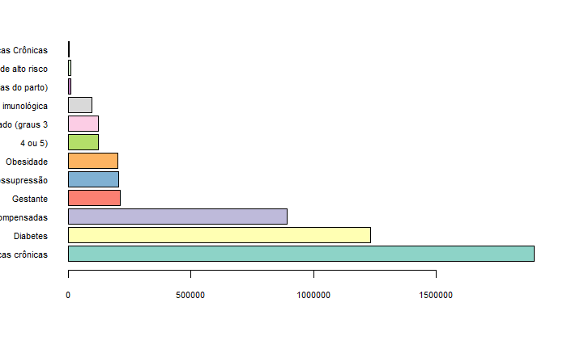

```r
colb = brewer.pal(12, "Set3")
barplot(sort(counts, decreasing = TRUE)[1:12], horiz = TRUE, las = 1, col = colb, cex.names = 0.7, cex.axis = 0.7)
```

```r
rm(counts, colb)
invisible(gc())
```

São tratados os dados por falta de padronização e também os nulos. Deletando os valores nulos e só ficando com condições que tem mais de 2000 dados. Os que têm menos são passados para a dimensão **Outros**.

```r
sort(counts, decreasing = TRUE)
```

```
                                            Doenças cardíacas crônicas
                                                               1905728
                                                              Diabetes
                                                               1231574
                         Doenças respiratórias crônicas descompensadas
                                                                894812
                  Doenças renais crônicas em estágio avançado (graus 3
                                                                250675
                                                              Gestante
                                                                221573
                                                       Imunossupressão
                                                                207008
                                                             Obesidade
                                                                201334
Portador de doenças cromossômicas ou estado de fragilidade imunológica
                                                                 95060
                                       Puérpera (até 45 dias do parto)
                                                                  9717
                                                                Outros
                                                                  8601
```

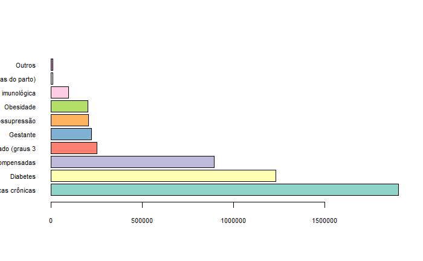

```r
colb = brewer.pal(12, "Set3")
barplot(sort(counts, decreasing = TRUE)[1:12], horiz = TRUE, las = 1, col = colb, cex.names = 0.7, cex.axis = 0.7)
```

```r
rm(counts, colb)
rm(dados)
invisible(gc())
```

Mudando os labels das categorías.

```r
save(dados, file = "output/qdscovid_conditions.Rda")

counts = table(dados$condicoes)

sort(counts, decreasing = TRUE)
```

[output not shown]

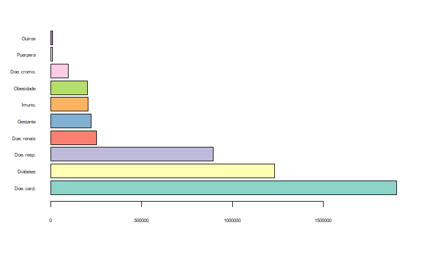

```r
colb = brewer.pal(12, "Set3")
barplot(sort(counts, decreasing = TRUE), horiz = TRUE, las = 1, col = colb, cex.names = 0.5, cex.axis = 0.5)
```

```r
rm(counts, colb)
rm(dados)
invisible(gc())
```

Limpando dados dos registros das condições.

```r
load("output/qdscovid_registers.Rda")
head(dados)
```

|  | dataNotificacao | dataInicioSintomas | profissionalSaude | condicoes | estadoTeste | dataTeste | tipoTeste | resultadoTeste | sexo | estadoIBGE | municipioIBGE | estadoNotificacaoIBGE | municipioNotificacaoIBGE | idade | dataEncerramento | evolucaoCaso | classificacaoFinal | sintomas_count | condicoes_count |
| --- | --- | --- | --- | --- | --- | --- | --- | --- | --- | --- | --- | --- | --- | --- | --- | --- | --- | --- | --- |
| 1 | 2020-04-20 | 2020-04-15 | Nao |  | Coletado | 2020-04-20 | Indefinido | Indefinido | Masculino | 12 | 1200450 | 12 | 1200401 | 51 | 2020-01-01 | Indefinido | Indefinido | 2 | 0 |
| 2 | 2020-04-21 | 2020-04-13 | Nao |  | Coletado | 2020-04-21 | Indefinido | Indefinido | Feminino | 12 | 1200450 | 12 | 1200401 | 47 | 2020-01-01 | Indefinido | Indefinido | 1 | 0 |
| 3 | 2020-04-22 | 2020-04-12 | Nao | Doenças cardíacas crônicas, Diabetes | Coletado | 2020-04-22 | Indefinido | Indefinido | Feminino | 12 | 1200401 | 12 | 1200401 | 57 | 2020-01-01 | Indefinido | Indefinido | 3 | 2 |
| 4 | 2020-03-18 | 2020-03-17 | Nao |  | Concluido | 2020-03-18 | RT-PCR | Positivo | Feminino | 12 | 1200401 | 12 | 1200401 | 27 | 2020-04-10 | Cura | Lab. | 3 | 0 |
| 5 | 2020-03-18 | 2020-03-18 | Sim |  | Concluido | 2020-03-19 | RT-PCR | Positivo | Masculino | 12 | 1200401 | 12 | 1200401 | 30 | 2020-04-10 | Cura | Lab. | 5 | 0 |
| 6 | 2020-03-24 | 2020-03-17 | Nao |  | Concluido | 2020-03-24 | RT-PCR | Positivo | Masculino | 12 | 1200401 | 12 | 1200401 | 34 | 2020-04-13 | Cura | Lab. | 1 | 0 |

```r
dados$condicoes = NULL
save(dados, file = "output/qdscovid_registers.Rda")
rm(dados)
invisible(gc())
```